# Chapter 8: Conservation Biology of the Wildbeest in the Serengeti

Ignacia Rivera on January 23, 2019

### **Question 1: What happens with the wildbeest population once rainfall reduces again?**

#### **Competing hypotheses:**

- The herd will collapse.
- The herd will not collapse.

#### **Equations:**

- Population growth - Logistic model

$$N_{t+1} = N_t + rN_t ( 1 - \frac{N_t}{K})$$

- We assume observation error

$$N_{obs,t} = N_t + V_t$$
where $V_t$ is normally distirbuted with mean 0 and sd $\sigma_t$

#### **Finding the best values for $r$ and $K$ for the logistic model:**

We assume the logistic model and observation uncertainty and find the parameters $r$ and $K$ that give us the best fit to the data by applying maximum likelihood estimation (minimizing Negative log likelihood).

```r
# Function that calculates negative likelihoods  Nt based on logistic model and initial parameters

nll.estimation <- function(R, K, N.0, start.year, end.year, pop){

 ## Calculates number of years
n.years <- end.year - start.year + 1
years <- c(seq(from= start.year, to = end.year))

# Predicting Nt based on logistic model

## storing vector
pred.pop <- array(data= NA, dim=c(n.years, length(K), length(R)), dimnames = list(years, K, R))
nll <- array(data= NA, dim=c(n.years, length(K), length(R)), dimnames = list(years, K, R))

## setting starting year
pred.pop[1, , ] <- N.0

for (r in 1:length(R)) {

  for (k in 1:length(K))  {

    for (y in 2:n.years)    {

      N.t <- pred.pop[y-1,k,r]

      N.t.1 <- N.t + (R[r]* N.t * (1-N.t/K[k]))#logistic growth under different K

      pred.pop[y,k,r] <- N.t.1

      year = start.year+ y -1

      if (year %in% pop$year) {

        N.obs = pop$N.obs[pop$year == year]
        sigma = pop$sigma[pop$year == year]

        nll.year = log(sigma) + 0.5* log(2*pi) + ((N.obs - N.t.1)^2)/(2*sigma^2)

        nll[y,k,r] <- nll.year

      } else {

      nll[y, k, r] <- 0

      }
    }

  }

}


return(nll)

}

# Logistic growth model

logistic.growth <- function(R, K, N.0, start.year, end.year){

   ## Calculates number of years and creates years sequence
n.years <- end.year - start.year + 1
years <- c(seq(from= start.year, to = end.year))

  ## Matrix to store results
  pred.pop <- rep(NA, n.years)
  ## Setting initial population
  pred.pop[1] <- N.0

  for (y in 2:n.years)    {

      N.t <- pred.pop[y-1]

      N.t.1 <- N.t + (R* N.t * (1-N.t/K))#logistic growth under different K

      pred.pop[y] <- N.t.1
  }

  pred.pop <- data.frame(year = years, pred.pop = pred.pop)
  return(pred.pop)

}
```

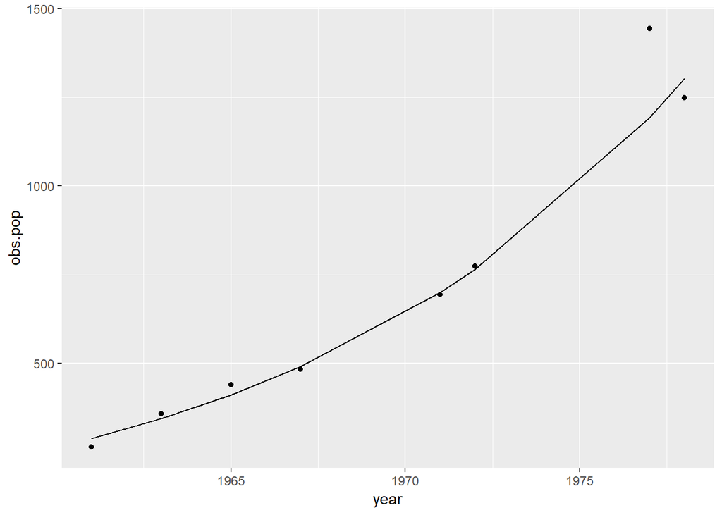

```r
# Initial parameters
R <- c(seq(from= 0.09, to = 0.15, by = 0.003))
K <- c(seq(from= 1000, to = 350000000, by =100000))
N.0 <- 263
start.year <- 1960
end.year <- 1979

# Data
census <- read.csv(here("ch_8/data/wildebeest_data.csv"))
colnames(census) <- c('year', 'rain', 'pop', 'sd', 'adult_mortality', 'calf_survival')

pop <- census %>% #dataframe with pop estimates and sigma per year
  filter(year < 1979 & pop != 'NA') %>%
  mutate(sigma = ifelse(is.na(sd), 0.3*pop, sd)) %>%
  select(year, N.obs = pop, sigma)


# Finding optimal parameters
nll <- nll.estimation(R, K, N.0, start.year, end.year, pop)
total_NLL <- apply(nll, c(2,3), sum, na.rm=TRUE)
K.optim <- K[which(total_NLL == min(total_NLL), 2)[1,1]]
r.optim <- R[which(total_NLL == min(total_NLL), 2)[1,2]]
total_NLL <-  total_NLL[2:21,]

# Fitting data with optimal parameters

pred.pop.opt <- logistic.growth(r.optim, K.optim, N.0, start.year, end.year) %>%
  filter(year %in% pop$year) %>%
  mutate(obs.pop = pop$N.obs)

ggplot(pred.pop.opt, aes(x = year)) +
  geom_point(aes(y = obs.pop)) +
  geom_line(aes(y = pred.pop))
```

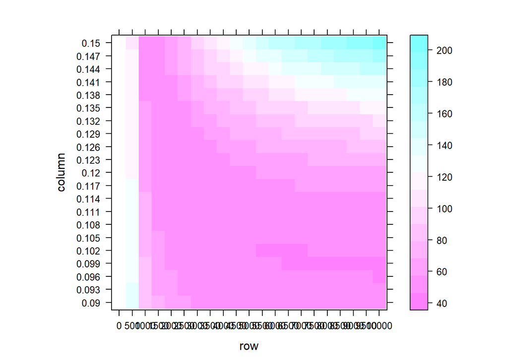

```r
# Plotting NLL to see how defined are parameters

K.1 <- c(seq(from= 0, to = 10000 , by =500))
nll.1 <- nll.estimation(R, K.1, N.0, start.year, end.year, pop)
total_NLL.1 <- apply(nll.1, c(2,3), sum, na.rm=TRUE)

levelplot(total_NLL.1)
```

This model does not allow us to understand what happens in the long term, and especially what would happen if rainfall changes. The data is already so well fitted that adding any more information will make no change. But we can conlclude that over the range of population sizes seen up to 1978 ther eis no evidence that the population rate was slowing.

#### **Finding the best values for $a$, $b$, $f$, $g$ for the life-history model:**

Now we use maximum likelihood estimation to fit a life-history model that is more likely to be sensitive to rainfall. Below are the components of the model:

- Total food per ha ($T_t$)

$$T_t= 1.25 R_t$$
Where $R_t$ is the total dry season rainfall (in mm).

- Food per animal ($F_t$)

$$F_t = \frac{T_t A}{N_t}$$

- Births in a year ($B_t$)

$$B_t = 0.4 N_t$$
* Survival Calf in a year ($s_{c, t}$)

$$s_{c, t} = \frac{aF_t}{b+F_t}$$

Where $a \le 1$ is the maximum value of calf survival and $b$ is the value of food per individual at which survival is 50% of $a$.

- Survival Adult in a year ($s_{a, t}$)

$$s_{a, t} = \frac{qF_t}{f+F_t}$$

##### *Life histoy model:*

$$N_{t+1} = (s_{a, t})N_t + (s_{c, t})B_t$$
$$N_{t+1} = N_t (\frac{g 1.25 R_t/N_t}{f + 1.25R_t/N_t}) + 0.4 N_t(\frac{a 1.25R_t/N_t}{b + 1.25R_t/N_t})$$

At equilibirum:

$$N_{eq} = \frac{-b' + \sqrt{(b')^2 - 4a'c'}}{2a'}$$
where $a' = bf, b'= 1.25R (b+f-gb -0.4af)$, and $c' = (1.25)^2(1-g-0.4a)$

$$N_{t+1 = }\left\{
\begin{array}{ll}
(s_{a, t})N_t + (s_{c, t})B_t & \quad t < 1977 \\
(s_{a, t})N_t + (s_{c, t})B_t - h_t & \quad t \geq 1977
\end{array}
\right.$$